# Población indígena en México

Ludwig Gerardo Rubio Jaime

### Introducción

Con frecuencia escuchamos sobre la riqueza natural de México, el quinto país más biodiverso del mundo, escuchamos sobre sus playas y sobre su historia y tradiciones, pero pocas veces se habla de su riqueza multicultural y ancestral presente, de sus más de **69 lenguas indígenas** que son tan diferentes entre ellas como el chino lo es del castellano, de sus **364 variantes lingüísticas**, y de que en México respecto el último censo oficial (INEGI, 2010), viven tantas personas que se auto-reconocen como indígena, que representan más de **dos veces la actual población de Madrid, España**.

### Contexto Histórico (1990-2010)

#### Nacional

Pero… ¿Qué sucede con la población indígena durante este período? Poco se habla de lo que sucede con los pueblos originarios en México, y solo en el año de 1994, con la apertura económica neoliberal del país, se les miró por su postura en oposición a los tratados de libre comercio.

Durante el período de 1990 a 2010, la población indígena no ha disminuido, al contrario, ha ido en crecimiento, sin embargo, la proporción de los pueblos originarios respecto a la población no indígena ha disminuido de forma considerable, y alcanza la cantidad de 7 millones de habitantes aproximadamente en el año de 2010.

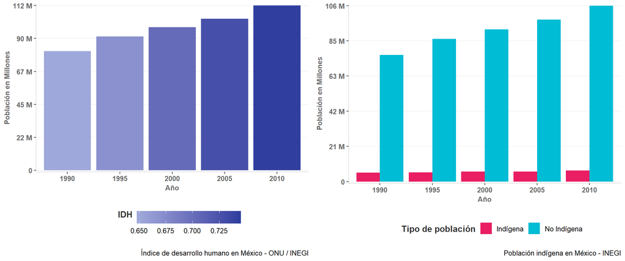

Al mismo tiempo que la proporción de indígenas ha disminuido respecto a la población no indígena durante estos 20 años, la pirámide poblacional del país ha cambiado considerablemente, cada vez nacen menos niños, y la población joven y adulta es cada vez mayor.

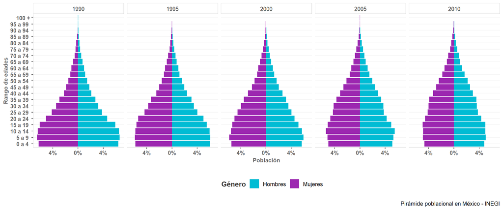

#### Por Entidad Federativa

Lo que se puede describiren común entre ellos y el contexto nacional es que no existe un solo estado que no replique el comportamiento nacional, donde durante este período de 20 años, disminuyó de manera proporcional la cantidad de habitantes indígenas en proporción a los habitantes no indígenas.

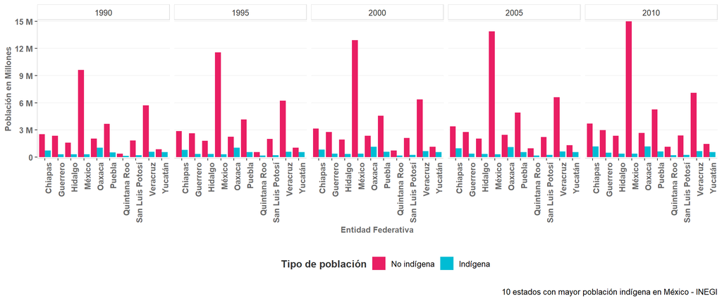

En México, el INEGI, genera un indicador llamado *índice de marginación*, que toma en cuenta el acceso a servicios de salud, educación, vivienda y calidad de vida en general, que suele asociarse a la pobreza y marginación de los pueblos. Dicho índice suele representarse en 5 categorías llamadas *grados de marginación*, siendo la que indica mayor acceso a servicios y vivienda el grado *Muy bajo*, y siendo el peor de los casos *Muy alto*.

Es bien conocido que los pueblos indígenas han sufrido de una marginación económica durante el desarrollo del México moderno, y esto se ve reflejado en que los estados con mayor población indígena, son los mismos que tienen un grado de marginación *Muy alto*, o *Alto*, situación que no permite su desarrollo y libertad para adaptarse a las cambiantes dinámicas del país y el mundo.

De los 10 estados con mayor población indígena, ninguna alcanzó en el año 2010 un grado de marginación *Muy bajo*, y salvo en el 2005 donde dos 2 estados tenían un grado de amrginación *Bajo*, solo 1 de los 10 estados (Estado de México), logró el nivel de grado de marginación *Bajo*, asociado sobre todo a su cercanía a la capital de país y el desarrollo de oportunidades en la región.

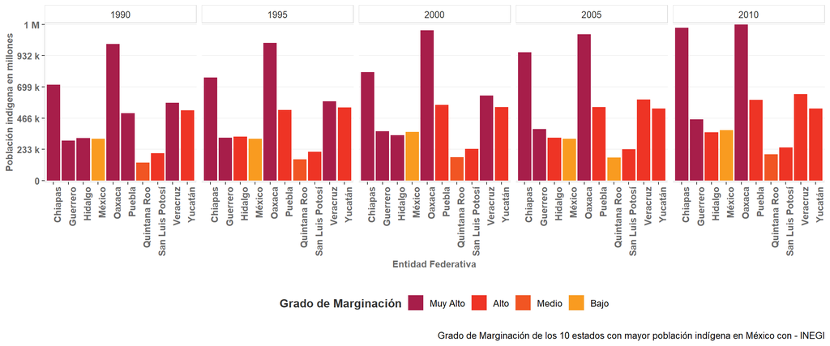

### Actualidad (2010)

#### Por Entidad Federativa

En el año 2010, año del último censo oficial, el sur de México era la zona más habitada por población indígena, llegando a conservar en alguno estados, aproximadamente una proporción de 30% en contraste con la población no indígena.

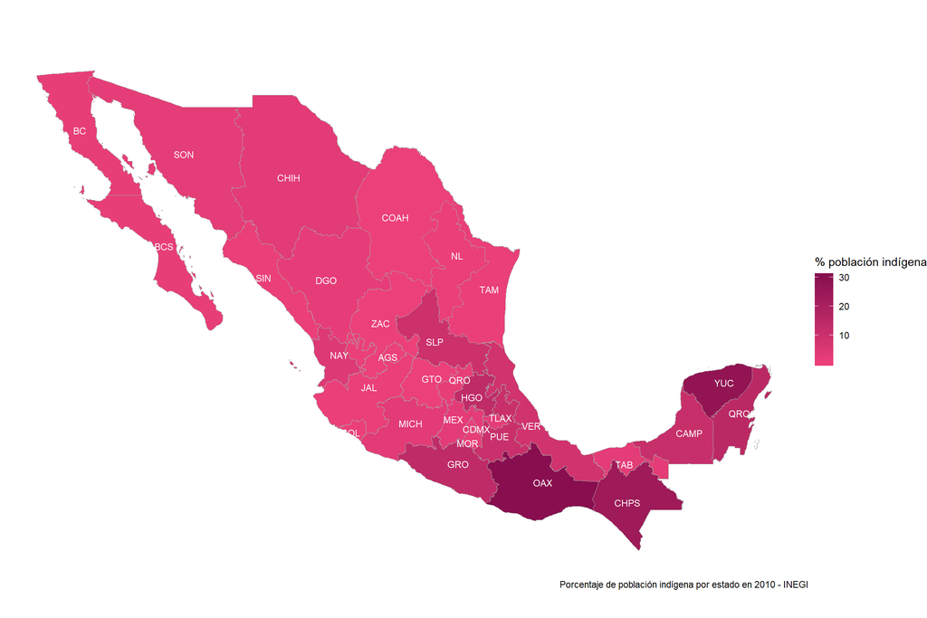

La ONU, en dicho año, realizó un esfuerzo conjunto con el gobierno del país para incluir en el censo la generación de un índice de desarrollo humano especial para los pueblos indígenas, que permitió concoer que no sólo existe una relación entre el índice de desarrollo de un estado y su población indígena, si no que las poblaciones indígenas de la mayoría de los estados tienen una peor calidad de vida que la población no indígena.

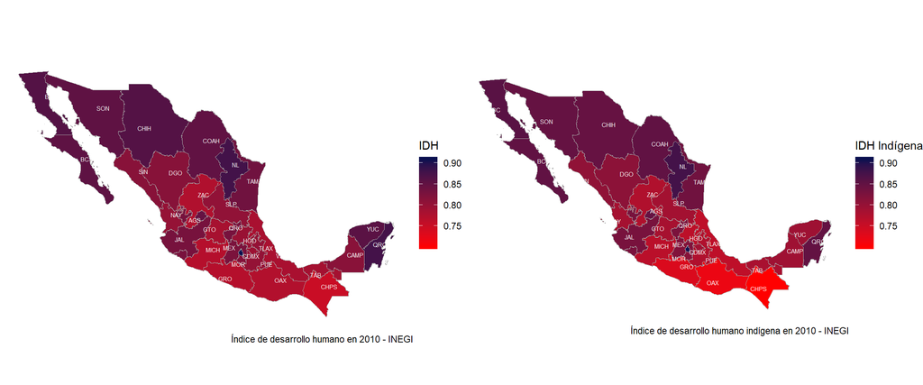

#### Por Lengua Indígena

Pero hablar de los pueblos indígenas como una misma unidad, resulta imposible cuando se conoce su contexto cultural, lingüístico, y geográfico, los pueblos se encuentran en regiones muy distantes unos de otros, tiene expresiones culturales y formas de vida muy distintas, así como en contraste, la convivencia de múltiples pueblos ha desdibujado diferencias entre ellos y ha dado paso a nuevas expresiones culturales.

Es entonces que la lengua se convierte en una forma de poder recabar información que se pueda contrastar, una herramienta utilizada con frecuencia por los antropólogos al ser el elemeto cultural que más fácilmente se puede organizar de forma taxonómica, entendiendo que de cualquier forma siempre existen diferencias significativas despendiendo la región y comunidad que la habla.

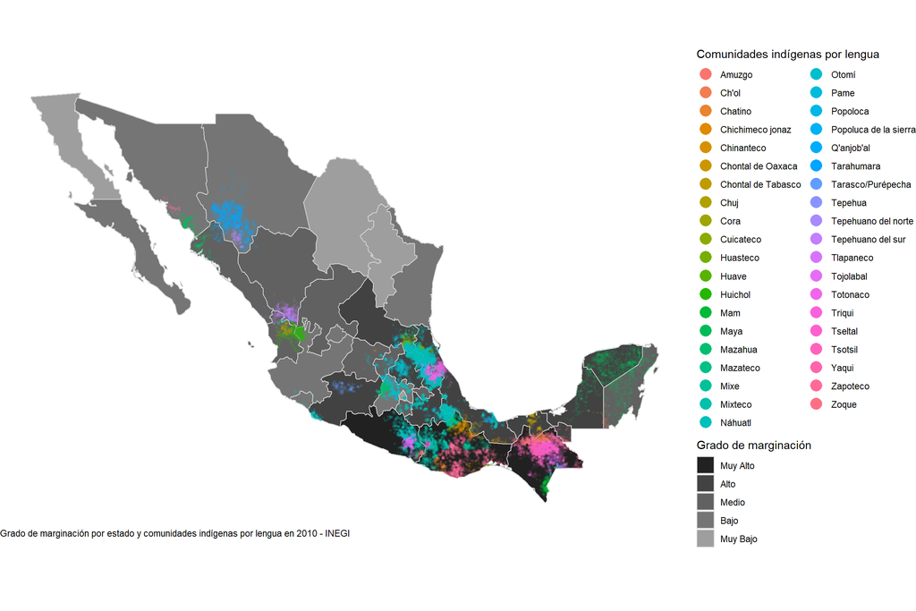

En 2010 los hablantes del Náhuatl eran cerca de 3 millones de personas, seguidos por los hablantes del maya con cerca de 1.5 millones de personas, mientras que algunos pueblos indígenas contaban con apenas cerca de 50 hablantes.

El acceso a servicio básicos como los son servicios de salud, agua potable, electricidad o acceso a internet son muy distintos para cada uno de ellos, por ejemplo:

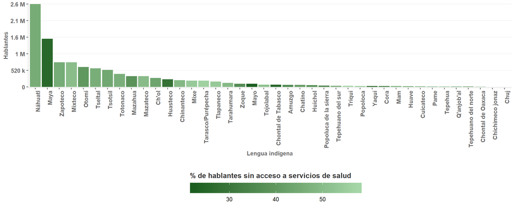

En cuanto al acceso de agua potable, la ubicación geográfica de los hablantes podría jugar un papel importante y contrastante a los servicios de salud, ya que en el sur de México existen una variada y rica fuente de agua, al mismo tiempo que la población es mucho menor a la que habita el centro del país, donde además las fuentes de agua son más escasas.

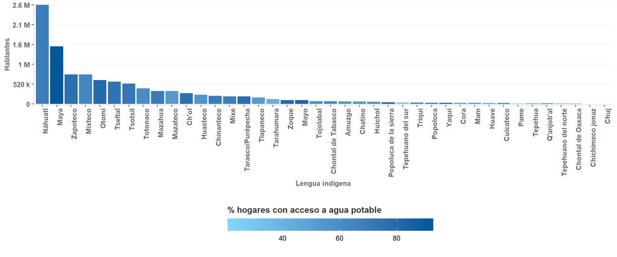

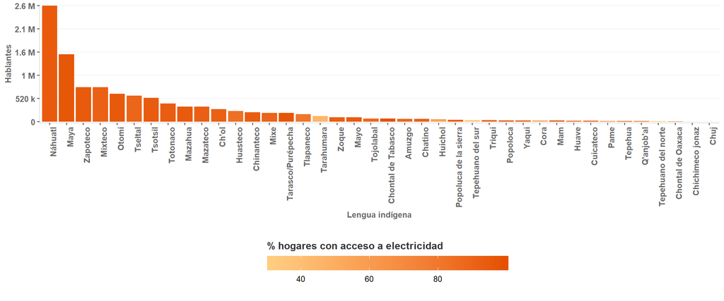

En contraste, muy poco porcentaje de población de los hablantes de cada lengua indígena cuentan con acceso a internet. En todos los casos es menor al 10% de la población hablante, siendo aquellos hablantes como los Mayas y Zapotecas los que tiene mayor acceso, debido quizá a dos factores: El apoyo internacional hacia los pueblos del sur de México, y a su cercanía a destinos de turismo internacional.

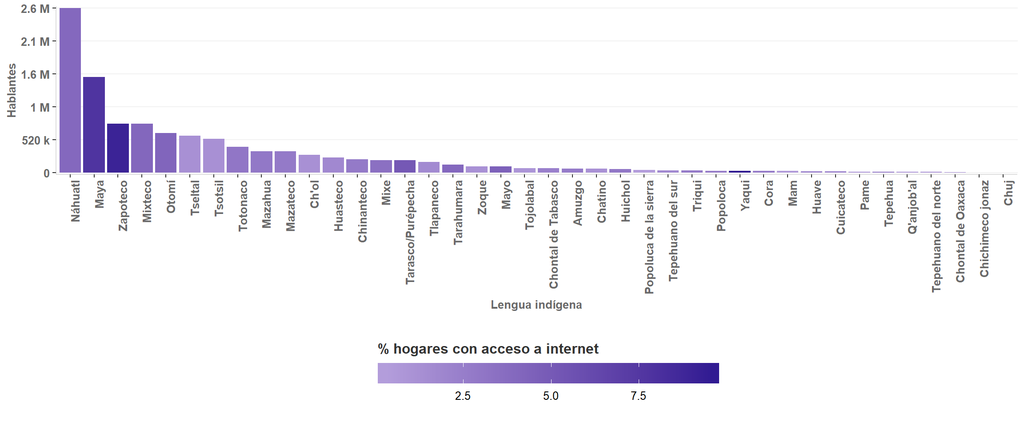

De esta manera es como los datos de distintas fuentes oficiales nos han permitido conocer el desarrollo y estado de los pueblos indígenas en México; nos permiten exponer y contrastar que las condiciones de vida y derechos de este sector poblacional en México, no están regidas en el marco de la igualdad y el respeto a los derechos de acceso a servicios y mejoramiento de la calidad de vida.